# The evaluation of genetic association studies

December 14th, 2016

## Introduction

## Genetic Association Studies

Goal: detect the association of genetic variants with a particular trait of interest, e.g. disease or quantitative trait

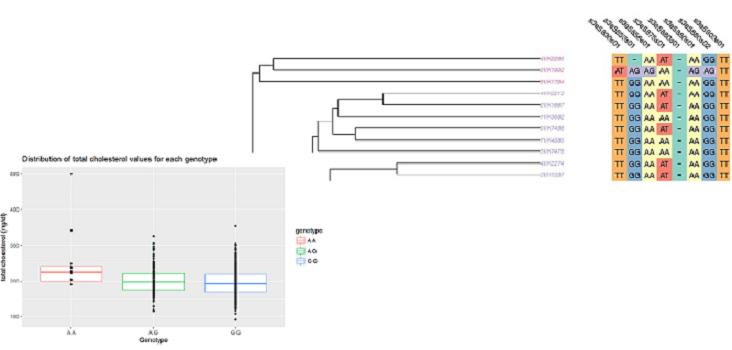

## Analysis strategies

Several statistical analysis strategies proposed (Balding 2006):

- binary trait
  - Pearson's \(\chi^{2}\)-square test for independence testing
  - the Cochran-Armitage trend test (Armitage 1955)
  - multiple two-by-two tables (Cheng and Lee 2014)
  - the 2 degrees of freedom likelihood ratio test based on logistic regression (Wellek and Ziegler 2012)
- quantitative traits - linear regression and the corresponding F-test
- count phenotypes - Poisson regression approach (Qu 2014)
- survival outcomes - tests based on the Cox proportional hazards model (Mendolia et al. 2014)

## The genetic mode on inheritance

Commonly three genetic modes of inheritance are considered (Freidlin et al. 2002):

- dominant model - assumes that either one or two copies of the minor allele are sufficient to produce an (equal) effect on the trait
- additive model - assumes that the trait effect is linearly related to the number of minor alleles
- recessive model - assumes that the trait effect is related to the presence of both minor alleles

In reality the mode of inheritance is rarely known **a-priori** in genetic association studies.

model-dependent methods: most powerful if the genetic model is specified correctly

model-free techniques: robust, but they are not as powerful

Combinations exists: unconditional maximum test (Freidlin et al. 2002), (L. A. Hothorn and Hothorn 2009), (Loley et al. 2013)

## Methods

## Methods

- consider an autosomal diallelic marker (e.g., SNP) with alleles \(A\) and \(a\).
- genotypes (\(AA\), \(Aa\) and \(aa\)) are represented by a quantitative explanatory variable \(x_{i}\), with \(i = 1,\ldots,n\) independent subjects
- \(x_{i}\) corresponds to the number of copies of the allele \(a\), i.e., if subject \(i\) has zero copies of the allele \(a\) then \(x_{i}=0\), and so on
- consider the generalized linear model (Nelder and Wedderburn 1972): \[ E(y_{i})=g^{-1}\left(x_{i} \beta + \mathbf{x}_{Ni}'\mathbf{\beta}_N\right) \] , with e.g. logit link, identity link, or proportional hazards model

## Multiple genetic models

Assess the effect of genotype on the trait under different modes of inheritance consider the following scores:

| genetic model | independent variable | AA | Aa | aa |
| --- | --- | --- | --- | --- |
| dominant | \(x^{(1)}\) | 0 | 1 | 1 |
| additive | \(x^{(2)}\) | 0 | 0.5 | 1 |
| recessive | \(x^{(3)}\) | 0 | 0 | 1 |

with the vector of all parameters \[\mathbf{\beta}^{j} = (\beta^{j}, \mathbf{\beta}_{N})\] with \(j = 1,2,3\)

## Testing marker effects

To test the genetic marker for its association with the phenotype of interest it is assumed that we are interested in the following null hypothesis

\[H_{0}^{(j)}: \hspace{0.5cm} \beta^{(j)}=\beta^{(j)}_{0}, \qquad j=1,2,3,\] Use the multiple marginal models approach of Pipper, Ritz, and Bisgaard (2012) (see also previous talks) to consider simultaneous inference on the parameter vectors from the three genetic models \(\mathbf{\beta^{(123)}}=(\mathbf{\beta^{(1)}}, \mathbf{\beta^{(2)}},\mathbf{\beta^{(3)}})\) (see also (So and Sham 2011, Kitsche, Ritz, and Hothorn (2016))).

## Applications

## Quantitative trait

The Bogalusa Heart Study dataset (Smith et al. 2010):

- 525 unrelated individuals of European descent at 545,821 SNPs.
- 12 clinically relevant phenotypes were measured
- considering phenotype total cholesterol (measured in milligrams (mg) of cholesterol per deciliter (dl) of blood ) for illustrative purposes
- SNP rs7738656 in the gene **C6orf170/GJA1**

## Bogalusa Heart Study

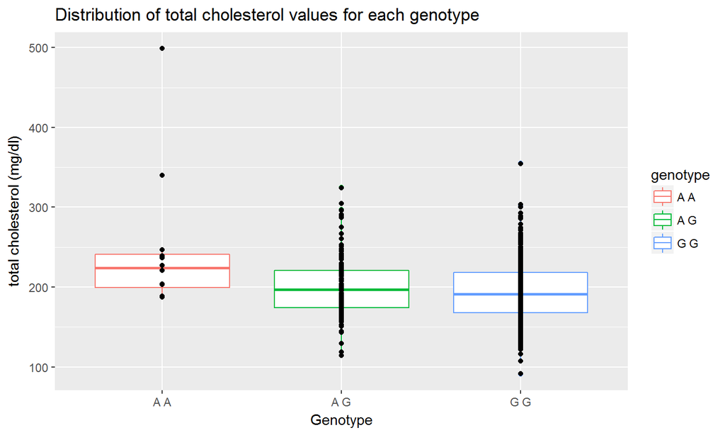

## Three genetic models

\[y_{i} \sim \beta_{1} + \beta_{2} x^{(j)}_{i} + \epsilon_{i} \hspace{0.5cm} j = 1,2,3\\\]

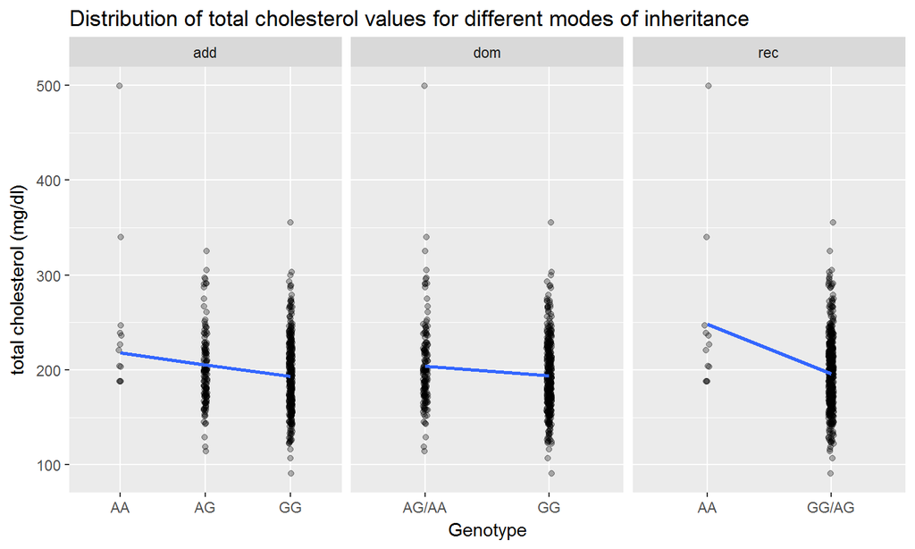

## Results - Quantitative trait

Results from the association analysis of the quantitative trait of total cholesterol with the SNP rs7738656.

| lhs | rhs | estimate | std.error | statistic | p.value |
| --- | --- | --- | --- | --- | --- |
| m1: add | 0 | 25.11 | 6.85 | 3.67 | 0.0005050 |
| m2: rec | 0 | 52.65 | 11.65 | 4.52 | 0.0000125 |
| m3: dom | 0 | 10.19 | 3.87 | 2.63 | 0.0170106 |

Conclusion: SNP rs7738656 is associated with the amount of total cholesterol with an effect of 52.65 mg/dl of the homozygous recessive genotype.

## Case-Control study

Genome-wide association study (GWAS) on severe falciparum malaria:

- association with SNP rs10900589 in the ATPase, Ca ++ transporting, plasma membrane 4 (*ATP2B4*) gene (Timmann et al. 2012, Loley et al. (2013))
- data of the SNP rs10900589 for the Gambian population (N = 2209):

| Genotypes | TT | GT | GG |
| --- | --- | --- | --- |
| Cases | 472 | 377 | 59 |
| Controls | 672 | 507 | 122 |

## Results - Case-Control study

\[\text{logit}(y_{i})= \beta_{0} + \beta_{1}x^{(j)}_{i}, \hspace{0.5cm} j = 1,2,3\\\] with \[\text{logit}(y_{i})=\text{log}(P(y_{i}=1)/(1-P(y_{i}=1))\], where \(P(y_{i}=1)\) is the probability that a randomly selected individual is diseased.

| lhs | rhs | estimate | std.error | statistic | p.value |
| --- | --- | --- | --- | --- | --- |
| m1: Dom | 0 | 0.01 | 0.09 | 0.15 | 0.98580 |
| m2: Add | 0 | 0.16 | 0.14 | 1.16 | 0.43604 |
| m3: Rec | 0 | 0.40 | 0.16 | 2.42 | 0.03541 |

## Survival Endpoint

Experiment on susceptibility to infection in mouse were considered (Boyartchuk et al. 2001):

- susceptibility of mice to *Listeria monocytogenes* infection was defined as the number of hours elapsed between injection and death of the animal
- Mice surviving after 264 hours were considered recovered from the disease
- A total number of 120 individuals was typed at 133 markers; we consider *D13Mit147* within here

## Kaplan-Meier curves for *D13Mit147*

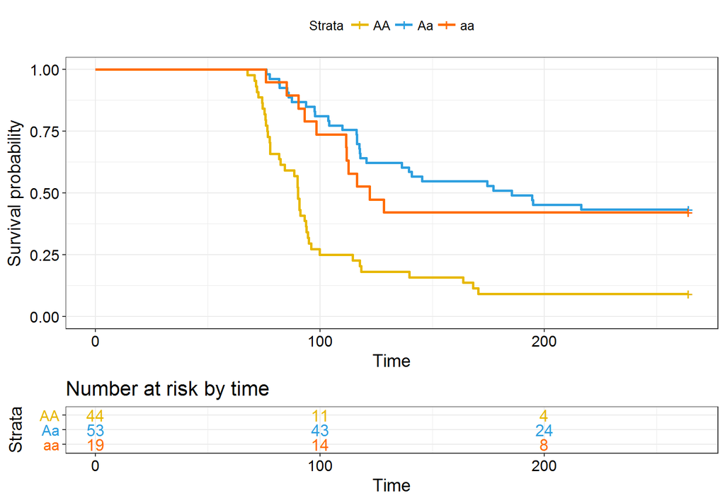

## Results - Survival endpoint

Consider three Cox proportional hazard models:

\[\lambda_{i}(t)=\lambda_{0}(t)e^{x^{(j)}_{i}\beta}, \hspace{0.5cm} j = 1,2,3\] where the exponentiated coefficients \(\text{exp}(\beta)\) represent the multiplicative change in risk due to the variable \(x^{(j)}_{i}\) under consideration

| lhs | rhs | estimate | std.error | statistic | p.value |
| --- | --- | --- | --- | --- | --- |
| m1: add | 0 | -1.65 | 0.37 | -4.44 | 0.0000179 |
| m2: rec | 0 | -0.39 | 0.32 | -1.20 | 0.4259772 |
| m3: dom | 0 | -1.25 | 0.23 | -5.50 | 0.0000001 |

## Overdominant Mode of Inheritance

Several other modes of inheritance were published in the scientific literature, see e.g., (Swanson-Wagner et al. 2006), i.e. overdominant genetic model (Q. Li et al. 2009):

| genetic model | independent variable | AA | Aa | aa |
| --- | --- | --- | --- | --- |
| dominant | \(x^{(1)}\) | 0 | 1 | 1 |
| additive | \(x^{(2)}\) | 0 | 0.5 | 1 |
| recessive | \(x^{(3)}\) | 0 | 0 | 1 |
| overdominant | \(x^{(4)}\) | 0 | 1 | 0 |

This mode of inheritance models an advantage of the heterozygous genotype over the homozygous genotypes.

## Overdominant Mode of Inheritance

Case-Control study of breast cancer (Hunter et al. 2007)

- genotyping 528,173 SNPs in 1,145 postmenopausal women of European ancestry with invasive breast cancer and 1,142 controls
- consider the SNP rs7696175

| Genotypes | AA | Aa | aa |
| --- | --- | --- | --- |
| Cases | 187 | 605 | 353 |
| Controls | 249 | 496 | 396 |

## Results - Overdominant Mode of Inheritance

\[\text{logit}(y_{i})= \beta_{0} + \beta_{1}x^{(j)}_{i}, \hspace{0.5cm} j = 1,2,3,4\]

| lhs | rhs | estimate | std.error | statistic | p.value |
| --- | --- | --- | --- | --- | --- |
| m1: Dom | 0 | -0.36 | 0.11 | -3.33 | 0.0026767 |
| m2: Add | 0 | -0.06 | 0.12 | -0.55 | 0.8560201 |
| m3: Rec | 0 | 0.18 | 0.09 | 1.97 | 0.1274600 |
| m4: OverDom | 0 | -0.38 | 0.08 | -4.48 | 0.0000153 |

## Interaction of Two Loci

Detection of epistatic effects: the phenomenon of the effect of one gene (locus) being dependent on the presence of one or more modifier genes

study from the data set *srdta* within the `GenABEL.data` package (GenABEL project developers 2013)

- results on a small region of about 2.5 Mb
- 833 SNPs are typed on 2500 people
- variables sex, age, two quantitative and one binary traits are available for analysis
- we focus on one quantitative trait (namely *qt1* in the package) the two SNPs rs10 and rs6585 and the covariates sex and age

## Interaction of Two Loci - The Model

\[y_{i}= \beta_{0} + \beta_{1}sex_{i} + \beta_{2}age_{i} + \beta_{3}x^{(j)}_{rs10 i} + \beta_{4}x^{(k)}_{rs6585 i} + \beta_{5}x^{(j)}_{rs10 i}\cdot x^{(k)}_{rs6585 i}, \hspace{0.5cm} j,k = 1,2,3\]

- where \(x^{(j)}_{rs10 i}\) is the appropriate coding for the genotype at locus rs10 for subject \(i\) assuming model \(j\)
- \(x^{(k)}_{rs6585 i}\) is coding for the genotype at locus rs6585, assuming model \(k\)
- the parameter \(\beta_{3}\) is the slope for the rs10 locus
- \(\beta_{4}\) is the slope specific to the rs6585 locus
- \(\beta_{5}\) is the interaction effect between locus rs10 and rs6585 for the \(j \times k\) model.

Our goal is now to make simultaneous inference on the parameter of the interaction effect \(\beta_{5}\) for all \(j \times k\) combinations of genetic models.

## Results - Interaction of Two Loci

| lhs | rhs | estimate | std.error | statistic | p.value |
| --- | --- | --- | --- | --- | --- |
| Additive x Additive | 0 | -0.64 | 0.27 | -2.38 | 0.0774743 |
| Dominant x Additive | 0 | -0.70 | 0.47 | -1.48 | 0.4559693 |
| Recessive x Additive | 0 | -0.30 | 0.15 | -2.00 | 0.1864984 |
| Additive x Dominant | 0 | -0.21 | 0.18 | -1.20 | 0.6495035 |
| Dominant x Dominant | 0 | -0.18 | 0.35 | -0.52 | 0.9742353 |
| Recessive x Dominant | 0 | -0.10 | 0.10 | -0.98 | 0.7908907 |
| Additive x Recessive | 0 | -0.91 | 0.29 | -3.16 | 0.0086826 |
| Dominant x Recessive | 0 | -0.85 | 0.42 | -2.00 | 0.1850936 |
| Recessive x Recessive | 0 | -0.47 | 0.17 | -2.78 | 0.0281787 |

## Conclusions

Summary:

- Multiple marginal models reflect different modes of inheritence
- Approach covers a wide variety of endpoints (binary, count, quantitative, and time-to-event data)
- Multiple endpoints of different types can be assessed simultaneously (analysis of pleiotropic effects)
- Multiple loci can be assessed simultaneously while taking different modes of inheritance into account (analysis of epistatic effects)
- General model formualtion allows the inclusion of additional covariates, e.g. population stratification
- Simultaneous confidence intervals for estimated parameters are available too (not presented)

Limitations:

- Applicable to a preselected subset of SNPs on GWAS
- Useful for candidate gene or candidate polymorphism studies

## Software

The functionality for the simultaneous inference for multiple marginal models is implemented in the R add-on package `library(multcomp)` (Hothorn, Bretz, and Westfall 2008)

All data sets available at:

```r
#install.packages("devtools")
library(devtools)
install_github("AKitsche/GAdata")
library(GAdata)
```

`.html` and `.Rmd` files for the slides at https://github.com/AKitsche/Talk_MMM_GA

## References

Armitage, P. 1955. “Tests for Linear Trends in Proportions and Frequencies.” *Biometrics* 11 (3): 375–86.

Balding, David J. 2006. “A tutorial on statistical methods for population association studies.” *Nature Reviews. Genetics* 7 (10): 781–91.

Boyartchuk, V L, K W Broman, R E Mosher, S E D’Orazio, M N Starnbach, and W F Dietrich. 2001. “Multigenic control of Listeria monocytogenes susceptibility in mice.” *Nature Genetics* 27 (3). Howard Hughes Medical Institute/Department of Genetics, Harvard Medical School, Boston, Massachusetts, USA.: 259–60.

Cheng, Kuang-Fu, and Jen-Yu Lee. 2014. “A Powerful and Robust Test in Genetic Association Studies.” *Human Heredity* 78 (1): 38–46.

Freidlin, B, G Zheng, Z Li, and J L Gastwirth. 2002. “Trend tests for case-control studies of genetic markers: power, sample size and robustness.” *Human Heredity* 53 (3): 146–52.

GenABEL project developers. 2013. *GenABEL: Genome-Wide Snp Association Analysis*. http://CRAN.R-project.org/package=GenABEL.

Hothorn, Ludwig A, and Torsten Hothorn. 2009. “Order-restricted scores test for the evaluation of population-based case-control studies when the genetic model is unknown.” *Biometrical Journal* 51 (4): 659–69.

Hothorn, Torsten, Frank Bretz, and Peter Westfall. 2008. “Simultaneous Inference in General Parametric Models.” *Biometrical Journal* 50 (3): 346–63.

Hunter, David J, Peter Kraft, Kevin B Jacobs, David G Cox, Meredith Yeager, Susan E Hankinson, Sholom Wacholder, et al. 2007. “A genome-wide association study identifies alleles in FGFR2 associated with risk of sporadic postmenopausal breast cancer.” *Nature Genetics* 39 (7): 870–74.

Kitsche, A., C. Ritz, and L.A. Hothorn. 2016. “A General Framework for the Evaluation of Genetic Association Studies Using Multiple Marginal Models.” *Human Heredity*, no. accepted for publication.

Li, Qizhai, Gang Zheng, Xueying Liang, and Kai Yu. 2009. “Robust tests for single-marker analysis in case-control genetic association studies.” *Annals of Human Genetics* 73 (2): 245–52.

Loley, Christina, Inke R König, Ludwig A. Hothorn, and Andreas Ziegler. 2013. “A unifying framework for robust association testing, estimation, and genetic model selection using the generalized linear model.” *European Journal of Human Genetics* 21 (12): 1442–8.

Mendolia, Franco, John P Klein, Effie W Petersdorf, Mari Malkki, and Tao Wang. 2014. “Comparison of statistics in association tests of genetic markers for survival outcomes.” *Statistics in Medicine* 33 (5): 828–44.

Nelder, Author J A, and R W M Wedderburn. 1972. “Generalized Linear Models.” *Journal of the Royal Statistical Society: Series A (General)* 135 (3): 370–84.

Pipper, Christian Bressen, Christian Ritz, and Hans Bisgaard. 2012. “A versatile method for confirmatory evaluation of the effects of a covariate in multiple models.” *Journal of the Royal Statistical Society: Series C (Applied Statistics)* 61 (2): 315–26.

Qu, Long. 2014. “Combining dependent F-tests for robust association of quantitative traits under genetic model uncertainty.” *Statistical Applications in Genetics and Molecular Biology* 13 (2): 123–39.

Smith, Erin N, Wei Chen, Mika Kähönen, Johannes Kettunen, Terho Lehtimäki, Leena Peltonen, Olli T Raitakari, et al. 2010. “Longitudinal genome-wide association of cardiovascular disease risk factors in the Bogalusa heart study.” *PLOS Genetics* 6 (9): e1001094.

So, Hon-Cheong, and Pak C Sham. 2011. “Robust association tests under different genetic models, allowing for binary or quantitative traits and covariates.” *Behavior Genetics* 41 (5): 768–75.

Swanson-Wagner, Ruth a, Yi Jia, Rhonda DeCook, Lisa a Borsuk, Dan Nettleton, and Patrick S Schnable. 2006. “All possible modes of gene action are observed in a global comparison of gene expression in a maize F1 hybrid and its inbred parents.” *Proceedings of the National Academy of Sciences of the United States of America* 103 (18): 6805–10.

Timmann, Christian, Thorsten Thye, Maren Vens, Jennifer Evans, Jürgen May, Christa Ehmen, Jürgen Sievertsen, et al. 2012. “Genome-wide association study indicates two novel resistance loci for severe malaria.” *Nature* 489 (7416): 443–46.

Wellek, Stefan, and Andreas Ziegler. 2012. “Cochran-Armitage test versus logistic regression in the analysis of genetic association studies.” *Human Heredity* 73 (1): 14–17.